# Poverty and Test Performance in New York Public Schools

MLDS Boot Camp - Final R Exercise

Haowen Chen

2026-09-21

## The question

The Department has asked:

> What can data tell us about the relationship between poverty and test performance in New York public schools?

with three follow-ups: how test performance differs between low, medium and high poverty areas; whether that relationship has changed over time; and whether access to free / reduced price lunch moderates it.

## Brainstorming (before looking at the data)

**Empathize - why is the stakeholder asking?** The Department allocates funding and support programs across districts. A documented poverty-performance gap is the evidence base for where those dollars go, and the free/reduced price lunch question is really asking whether an existing intervention appears to help.

**Brainstorm - what would help answer it?** County-level poverty rates joined to school-level test results; a scatter of school performance against free/reduced lunch share; average standardized scores by poverty tier, faceted or coloured by year to show change over time.

**Expected insights.** I expect a clear negative association between county poverty and test performance, fairly stable across years, and a lunch-access relationship that is confounded with poverty rather than obviously protective on its own - the schools with the most lunch access are also the poorest. Worth stating up front so I do not read the confound as an effect later.

## Project structure

```
final_r_exercise/
├── final_r_exercise.Rproj
├── run_all.R              # runs the pipeline from a fresh session
├── README.md
├── analysis_notebook.Rmd  # this file
├── data/
│   ├── raw/               # nys_schools.csv, nys_acs.csv (downloaded, untouched)
│   └── processed/         # outputs of the cleaning / merging steps
├── scripts/
│   ├── 0_import.R         # Task 1 - read the raw CSVs
│   ├── 1_clean.R          # Task 3 - missing values, poverty groups, z-scores
│   ├── 2_transform.R      # Task 4 - join schools + ACS
│   ├── 3_analyze.R        # Task 5 - summary tables
│   └── 4_plot.R           # Task 6 - visualizations
└── output/                # saved figures
```

One script per job, each loading the tidyverse itself, so any step can be re-run without sourcing the whole chain by hand.

## Task 1: Import the data

The two raw files are downloaded into `data/raw/` and left exactly as they came:

- `nys_schools.csv` - school-level records from the [NYS Department of Education](http://data.nysed.gov/downloads.php)
- `nys_acs.csv` - county-level American Community Survey data from the US Census Bureau

`read_csv()` is used rather than base `read.csv()`: it returns a tibble, keeps character columns as characters, and reports the column types it inferred. The `-99` missing-value code is *not* touched at this stage - the import is a faithful copy of what is on disk, and recoding belongs in the cleaning script.

```r
source(file.path("scripts", "0_import.R"))
```

## Task 2: Explore the data

```r
glimpse(nys_schools)
```

```
## Rows: 35,663
## Columns: 12
## $ school_cd         <chr> "010100010014", "010100010014", "010100010014", "010…
## $ school_name       <chr> "MONTESSORI MAGNET SCHOOL", "MONTESSORI MAGNET SCHOO…
## $ district_name     <chr> "ALBANY CITY SCHOOL DISTRICT", "ALBANY CITY SCHOOL D…
## $ county_name       <chr> "ALBANY", "ALBANY", "ALBANY", "ALBANY", "ALBANY", "A…
## $ region            <chr> "CAPITAL DISTRICT", "CAPITAL DISTRICT", "CAPITAL DIS…
## $ year              <dbl> 2008, 2009, 2010, 2011, 2012, 2013, 2014, 2015, 2016…
## $ total_enroll      <dbl> 316, 312, 300, 326, 294, 321, 335, 347, 366, 359, 28…
## $ per_free_lunch    <dbl> 0.33, 0.32, 0.26, 0.22, 0.31, 0.25, 0.35, 0.22, 0.29…
## $ per_reduced_lunch <dbl> 0.10, 0.08, 0.08, 0.07, 0.06, 0.08, 0.04, 0.00, 0.02…
## $ per_lep           <dbl> 0.01, 0.02, 0.03, 0.03, 0.03, 0.03, 0.06, 0.06, 0.05…
## $ mean_ela_score    <dbl> 658.0000, 672.6667, 670.3333, 666.6667, 670.3333, 30…
## $ mean_math_score   <dbl> 669.6667, 678.6667, 683.0000, 681.3333, 687.3333, 31…
```

`nys_schools` has 35,663 rows and 12 columns: identifiers (`school_cd`, `school_name`, `district_name`, `county_name`, `region`), `year`, and the numeric measures (`total_enroll`, `per_free_lunch`, `per_reduced_lunch`, `per_lep`, `mean_ela_score`, `mean_math_score`). One school-year per row.

```r
glimpse(nys_acs)
```

```
## Rows: 496
## Columns: 5
## $ county_name             <chr> "ALBANY", "ALBANY", "ALBANY", "ALBANY", "ALBAN…
## $ year                    <dbl> 2009, 2010, 2011, 2012, 2013, 2014, 2015, 2016…
## $ county_per_poverty      <dbl> 0.1183511, 0.1194052, 0.1207243, 0.1237525, 0.…
## $ median_household_income <dbl> 55350, 56090, 57715, 59359, 59394, 59940, 5988…
## $ county_per_bach         <dbl> 0.19036819, 0.19718856, 0.19898258, 0.19755045…
```

`nys_acs` is much smaller - 496 rows, 5 columns - one county-year per row: `county_name`, `year`, `county_per_poverty`, `median_household_income`, `county_per_bach`.

**Missing data.** The codebook says missing values are coded `-99` rather than `NA`, so a plain `is.na()` undercounts them. Counting `-99` directly:

```r
count_neg99 <- function(x) if (is.numeric(x)) sum(x == -99, na.rm = TRUE) else sum(x == "-99", na.rm = TRUE)

sapply(nys_schools, count_neg99)
```

```
##         school_cd       school_name     district_name       county_name
##                 0                 0                19                19
##            region              year      total_enroll    per_free_lunch
##                19                 0                13                15
## per_reduced_lunch           per_lep    mean_ela_score   mean_math_score
##                15                13              2208              2210
```

A few things stood out:

- `mean_ela_score` and `mean_math_score` are `-99` for ~2,200 rows each (about 6% of school-years) - schools that didn’t administer/report a test that year.
- Oddly, `-99` also shows up as the *string* `"-99"` in three character columns (`county_name`, `district_name`, `region`), all in the same 19 rows - a school record with no location info at all.
- `district_name` also has real `NA`s (about 1,700, unrelated to `-99`) - these turned out to be charter schools, which don’t belong to a traditional district, so a blank district is legitimate rather than missing data.
- `nys_acs` has no `-99` values at all - it’s a much cleaner extract.
- `county_per_poverty` ranges from about 4.7% to 30%, with a median around 12.9%.
- `per_free_lunch` and `per_reduced_lunch` are meant to be proportions (0-1), but 44 and 2 rows respectively exceed 1 - most are mild overshoots (1.01-1.87, likely rounding/double-counting), plus a couple of extreme outliers (257, 53) that are clearly data-entry errors.

```r
nys_schools %>% filter(per_free_lunch > 1 | per_reduced_lunch > 1) %>%
  select(school_name, year, per_free_lunch, per_reduced_lunch) %>%
  arrange(desc(per_free_lunch))
```

```
## # A tibble: 44 × 4
##    school_name                             year per_free_lunch per_reduced_lunch
##    <chr>                                  <dbl>          <dbl>             <dbl>
##  1 CENTRAL ISLIP EARLY CHILDHOOD CENTER    2012         257                53
##  2 EAST RAMAPO EARLY CHILDHOOD CENTER      2013          22.1               2.18
##  3 REACH ACADEMY (THE)                     2013           2.38              0
##  4 LITTLE SCHOOL                           2012           1.87              0.07
##  5 GREENBURGH ELEVEN MIDDLE SCHOOL         2013           1.83              0
##  6 EUGENIO MARIA DE HOSTOS MICROSOCIETY …  2012           1.76              0.07
##  7 LINDEN HILL SCHOOL                      2012           1.53              0.04
##  8 HANCOCK ELEMENTARY SCHOOL               2013           1.43              0.58
##  9 MOUNT PLEASANT-COTTAGE SCHOOL           2013           1.42              0
## 10 EDENWALD SCHOOL                         2013           1.34              0
## # ℹ 34 more rows
```

## Task 3: Recoding and variable manipulation

```r
source(file.path("scripts", "1_clean.R"))
```

`scripts/1_clean.R` does the following:

**1. Drop exact duplicate rows.** `distinct()` removes 24 fully duplicated rows in `nys_schools` (identical in every column) before anything else, so they aren’t double-counted later.

**2. Recode `-99` to `NA`.** The three character columns that store `-99` as a literal string (`county_name`, `district_name`, `region`) are handled explicitly with `na_if()`; every numeric column is handled in one pass with `across(where(is.numeric), ~ na_if(.x, -99))`.

**Lunch percentages above 1 set to `NA`.** `per_free_lunch` / `per_reduced_lunch` should be proportions (0-1); values above 1 (up to 257) are treated as unreliable and set to `NA` rather than capped, since there’s no way to tell which out-of-range values are close to correct and which are outright errors.

```r
nys_schools_clean %>% summarise(max_free = max(per_free_lunch, na.rm = TRUE), max_reduced = max(per_reduced_lunch, na.rm = TRUE))
```

```
## # A tibble: 1 × 2
##   max_free max_reduced
##      <dbl>       <dbl>
## 1        1        0.93
```

**3. Poverty groups.** Counties are split into `"low"` / `"medium"` / `"high"` poverty tertiles using `dplyr::ntile(county_per_poverty, 3)`, computed **within each year** (`group_by(year)`). Tertiles were chosen over a fixed cutoff (e.g. “poverty > 20% = high”) because they guarantee balanced group sizes regardless of how the poverty distribution shifts, and splitting within year rather than pooling all years keeps “high poverty” meaning “relatively poor compared to other counties *that year*” - useful since we also want to look at whether the poverty/performance relationship holds up over time.

```r
nys_acs_clean %>% count(year, poverty_group) %>% pivot_wider(names_from = poverty_group, values_from = n)
```

```
## # A tibble: 8 × 4
##    year   low medium  high
##   <dbl> <int>  <int> <int>
## 1  2009    21     21    20
## 2  2010    21     21    20
## 3  2011    21     21    20
## 4  2012    21     21    20
## 5  2013    21     21    20
## 6  2014    21     21    20
## 7  2015    21     21    20
## 8  2016    21     21    20
```

**4. Standardized test scores.** The state’s exam changes from year to year, so raw scale scores aren’t comparable across years. `mean_math_score` and `mean_ela_score` are converted to within-year z-scores (`group_by(year)` + `scale()`), so a value of e.g. `+1` means “one SD above that year’s average” no matter which year it is.

```r
nys_schools_clean %>%
  group_by(year) %>%
  summarise(math_mean = mean(math_z, na.rm = TRUE), math_sd = sd(math_z, na.rm = TRUE)) %>%
  head()
```

```
## # A tibble: 6 × 3
##    year math_mean math_sd
##   <dbl>     <dbl>   <dbl>
## 1  2008  5.21e-14   1.000
## 2  2009  3.75e-14   1.00
## 3  2010 -6.74e-14   1.000
## 4  2011  1.14e-14   1.000
## 5  2012  7.28e-14   1
## 6  2013 -5.11e-15   1.00
```

Each year’s `math_z` has mean ~0 and SD 1, as expected.

The cleaned tables are saved to `data/processed/nys_schools_clean.csv` and `data/processed/nys_acs_clean.csv`.

## Task 4: Merge the datasets

```r
source(file.path("scripts", "2_transform.R"))
```

**Join key:** `county_name` + `year`. All 62 county names match exactly between the two files, so no name-cleaning was needed before joining.

**Join type:** `left_join(nys_schools_clean, nys_acs_clean, ...)`, with schools as the base table. `nys_schools_clean` spans 2008-2017 but `nys_acs_clean` only covers 2009-2016, so a `left_join` keeps every school record and leaves the ACS columns `NA` for years outside that range, rather than an `inner_join` silently dropping those school-years entirely.

```r
nys_merged %>% summarise(
  n_rows          = n(),
  n_no_acs_match  = sum(is.na(county_per_poverty)),
  pct_no_acs_match = round(100 * n_no_acs_match / n_rows, 1)
)
```

```
## # A tibble: 1 × 3
##   n_rows n_no_acs_match pct_no_acs_match
##    <int>          <int>            <dbl>
## 1  35639           7089             19.9
```

About 20% of rows (school-years from 2008 and 2017) have no county-level data as a result. This is a real coverage gap in the ACS source, not a join bug – worth keeping in mind since it means the poverty-related tables and plots below implicitly cover 2009-2016 only.

The merged dataset is saved to `data/processed/nys_merged.csv`.

## Task 5: Summary tables

```r
source(file.path("scripts", "3_analyze.R"))
```

```
## # A tibble: 62 × 4
##    county_name    total_enrollment pct_free_reduced_lunch pct_poverty
##    <chr>                     <dbl>                  <dbl>       <dbl>
##  1 BRONX                    164613                  0.860       0.287
##  2 KINGS                    231798                  0.790       0.224
##  3 MONTGOMERY                 4959                  0.535       0.178
##  4 CHAUTAUQUA                13328                  0.548       0.175
##  5 TOMPKINS                   7988                  0.418       0.175
##  6 NEW YORK                 104857                  0.692       0.172
##  7 CATTARAUGUS                9370                  0.513       0.165
##  8 SULLIVAN                   6441                  0.503       0.164
##  9 SAINT LAWRENCE            11019                  0.524       0.164
## 10 OSWEGO                    13689                  0.510       0.162
## # ℹ 52 more rows
```

```
## # A tibble: 10 × 6
##    poverty_rank        county_name pct_poverty pct_free_reduced_lunch mean_ela_z
##    <chr>               <chr>             <dbl>                  <dbl>      <dbl>
##  1 Top 5 (highest pov… BRONX            0.287                   0.860    -0.781
##  2 Top 5 (highest pov… KINGS            0.224                   0.790    -0.285
##  3 Top 5 (highest pov… MONTGOMERY       0.178                   0.535    -0.507
##  4 Top 5 (highest pov… CHAUTAUQUA       0.175                   0.548    -0.237
##  5 Top 5 (highest pov… TOMPKINS         0.175                   0.418     0.0720
##  6 Bottom 5 (lowest p… NASSAU           0.0556                  0.225     0.887
##  7 Bottom 5 (lowest p… PUTNAM           0.0576                  0.148     0.651
##  8 Bottom 5 (lowest p… SUFFOLK          0.0619                  0.275     0.361
##  9 Bottom 5 (lowest p… SARATOGA         0.0640                  0.217     0.631
## 10 Bottom 5 (lowest p… DUTCHESS         0.0836                  0.333     0.0856
## # ℹ 1 more variable: mean_math_z <dbl>
```

**Table 5.1 – one row per county:** total enrollment, % of students on free/reduced lunch, % of the county population in poverty. Each number is a county-year average first, then averaged again across all years available, so one county isn’t over- or under-represented just because it has more years of data than another.

```r
table_county_summary %>% arrange(desc(pct_poverty))
```

```
## # A tibble: 62 × 4
##    county_name    total_enrollment pct_free_reduced_lunch pct_poverty
##    <chr>                     <dbl>                  <dbl>       <dbl>
##  1 BRONX                    164613                  0.860       0.287
##  2 KINGS                    231798                  0.790       0.224
##  3 MONTGOMERY                 4959                  0.535       0.178
##  4 CHAUTAUQUA                13328                  0.548       0.175
##  5 TOMPKINS                   7988                  0.418       0.175
##  6 NEW YORK                 104857                  0.692       0.172
##  7 CATTARAUGUS                9370                  0.513       0.165
##  8 SULLIVAN                   6441                  0.503       0.164
##  9 SAINT LAWRENCE            11019                  0.524       0.164
## 10 OSWEGO                    13689                  0.510       0.162
## # ℹ 52 more rows
```

**Table 5.2 – top 5 / bottom 5 counties by poverty rate:** poverty rate, free/reduced lunch %, and mean standardized ELA/math performance, side by side. Z-scores are used because the raw state test scale changes across years and cannot be averaged meaningfully over the full period.

```r
table_top_bottom_poverty
```

```
## # A tibble: 10 × 6
##    poverty_rank        county_name pct_poverty pct_free_reduced_lunch mean_ela_z
##    <chr>               <chr>             <dbl>                  <dbl>      <dbl>
##  1 Top 5 (highest pov… BRONX            0.287                   0.860    -0.781
##  2 Top 5 (highest pov… KINGS            0.224                   0.790    -0.285
##  3 Top 5 (highest pov… MONTGOMERY       0.178                   0.535    -0.507
##  4 Top 5 (highest pov… CHAUTAUQUA       0.175                   0.548    -0.237
##  5 Top 5 (highest pov… TOMPKINS         0.175                   0.418     0.0720
##  6 Bottom 5 (lowest p… NASSAU           0.0556                  0.225     0.887
##  7 Bottom 5 (lowest p… PUTNAM           0.0576                  0.148     0.651
##  8 Bottom 5 (lowest p… SUFFOLK          0.0619                  0.275     0.361
##  9 Bottom 5 (lowest p… SARATOGA         0.0640                  0.217     0.631
## 10 Bottom 5 (lowest p… DUTCHESS         0.0836                  0.333     0.0856
## # ℹ 1 more variable: mean_math_z <dbl>
```

## Task 6: Data visualization

```r
source(file.path("scripts", "4_plot.R"))
```

Building these plots surfaced two data-quality issues beyond what Task 3 covered:

- **42 school-years have `per_free_lunch + per_reduced_lunch > 1`** (up to 186% combined), even though each column individually is <= 1 – a logical impossibility that the single-column check in `1_clean.R` didn’t catch. These 42 rows are excluded from the scatter plot below only (not from the saved processed data), so the x-axis doesn’t run past 100%.
- **A handful of schools have extreme z-scores** (as low as -11.7 SD) – e.g. EDENWALD SCHOOL, a residential/juvenile-justice facility in the Bronx. That’s plausibly a genuinely atypical student population rather than a data error, so these are left untouched in every table and plot; it’s noted here as a limitation rather than corrected.

**Plot 1 – lunch access vs. test performance, at the school level:**

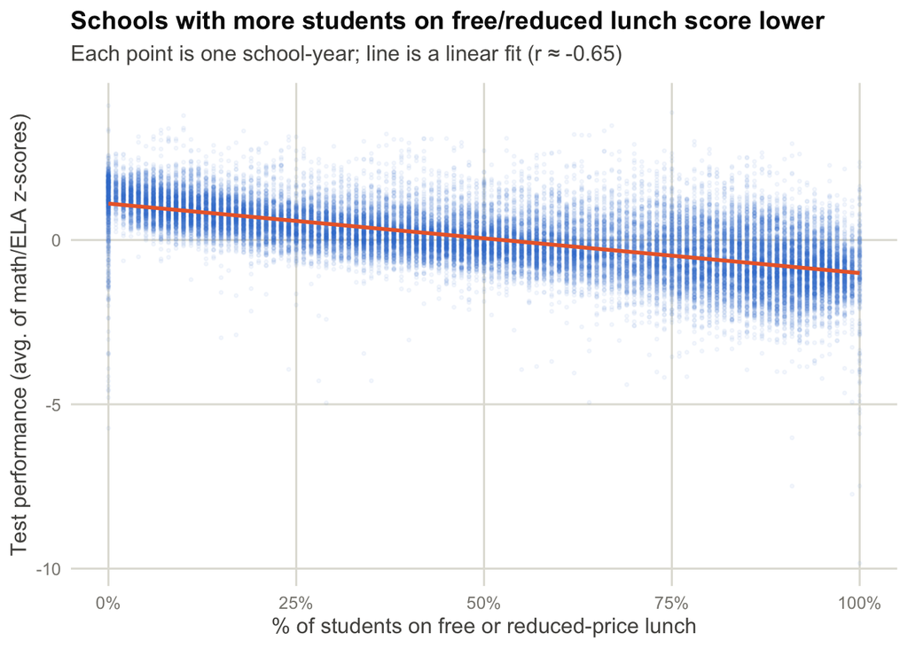

**Plot 2 – average test performance by county poverty group:**

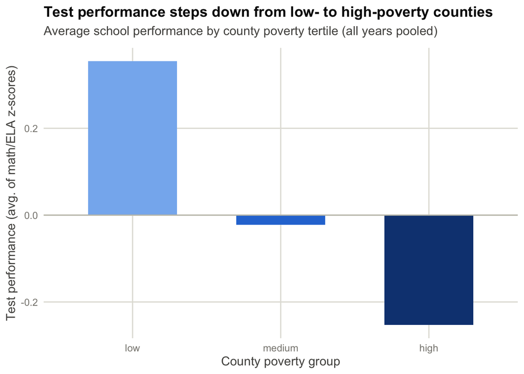

**Plot 3 (bonus) – has the gap changed over time?**

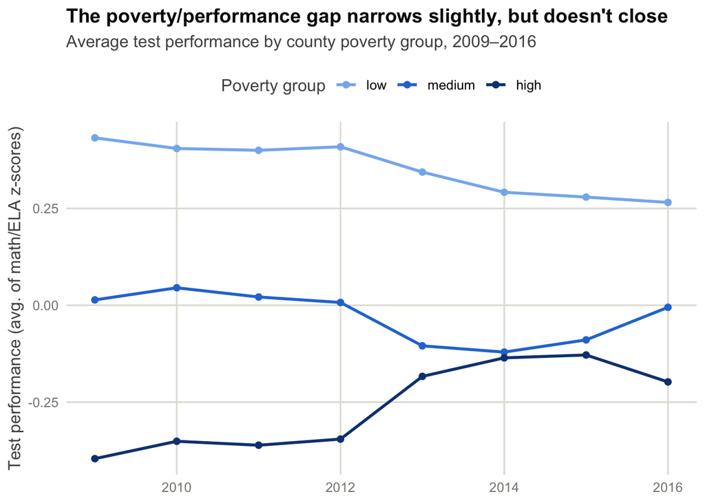

All three figures are also saved to `output/` as PNGs.

## Task 7: Findings

**Conclusion:** Higher-poverty settings have lower average test performance. The low- versus high-poverty difference is about 0.61 standard deviations overall, and it remains visible in 2016 even after narrowing from its 2009 level. Free/reduced-price lunch eligibility is also strongly associated with lower scores, but this descriptive analysis does **not** establish that lunch access changes the strength of the poverty-performance relationship.

### Evidence at a glance

| Measure | Data result |
| --- | --- |
| County poverty vs. test performance | r = -0.33 |
| Free/reduced-lunch share vs. test performance | r = -0.66 |
| County poverty vs. lunch share | r = 0.62 |
| Mean performance: low / medium / high poverty | +0.36 / -0.02 / -0.25 z |
| Low- vs. high-poverty gap: 2009 / 2016 | 0.83 / 0.46 z (44% narrower) |
| Exploratory poverty x lunch interaction | p = 0.061 |

### What can data tell us about the relationship between poverty and test performance in New York public schools?

**Higher poverty is associated with lower test performance, although these data do not prove that poverty causes lower scores.** Across the complete school-year records, county poverty and average math/ELA performance have a correlation of **r = -0.33**. At the school level, the share of students qualifying for free/reduced-price lunch has an even stronger negative correlation with performance (**r = -0.66**; Plot 1). The spread of scores at every poverty and lunch level shows that economic disadvantage is important, but it is not the only factor related to school performance.

### What’s the difference in test performance between low, medium and high poverty areas?

**Performance decreases at each step from low- to high-poverty counties.** Average school-level math/ELA performance is **+0.36 z** in low-poverty counties, **-0.02 z** in medium-poverty counties, and **-0.25 z** in high-poverty counties (Plot 2). The low- versus high-poverty difference is therefore **0.61 standard deviations**, a substantial descriptive gap.

### Has this relationship changed over time?

**The gap is smaller at the end of the period, but it does not disappear.** The low- versus high-poverty difference falls from **0.83 z in 2009** to **0.46 z in 2016**, a reduction of approximately **44%** (Plot 3). This is an endpoint comparison rather than evidence of a steady or causal trend, but it shows that the observed gap was meaningfully narrower in 2016 while remaining large.

### Is this relationship at all moderated by access to free/reduced price lunch?

**This analysis does not find clear evidence that lunch eligibility moderates the poverty-performance relationship.** County poverty and the school free/reduced-lunch share are themselves strongly related (**r = 0.62**), which makes their separate roles difficult to isolate. In an exploratory model with poverty, lunch share, their interaction, and year indicators, the interaction has **p = 0.061**. That is just above the conventional 0.05 threshold, so the correct conclusion is **inconclusive evidence of moderation**, not proof that moderation is absent. A stronger answer would require a model designed for repeated school observations and additional school/community covariates.

### Limitations

- The merged dataset only has complete poverty/lunch data for 2009-2016; 2008 and 2017 school records exist but can’t be placed into a poverty group.
- A few schools (e.g. residential/juvenile-justice facilities) have extreme scores that weren’t corrected or removed – they’re real data points, but atypical ones, and readers should keep that in mind since they are included in the analysis above.
- Everything here is a correlational read of aggregated school- and county-level averages, not a causal or student-level analysis – it says where the gaps are, not what’s driving them or what would close them.
- The moderation model is exploratory and treats repeated school-year observations as independent. Its p-value should be read as a screening result, not a definitive policy finding.